# Clinical Validation of Digital Healthcare Solutions State of the Art, Challenges and Opportunities

Bibliometric and visual analysis. Statistical report

Jordi Real. Impuls digital

26 abril, 2024

DRAFT

# Objective

To review the state of the art of clinical validation of digital solutions in the field of healthcare. The different methods used to assess the clinical effectiveness and safety of these solutions will be explored, as well as the common challenges encountered in this process. Additionally, best practices in clinical validation will be identified, and future perspectives for a more effective approach in this constantly evolving field will be discussed.

# Status

### Done

- Definition of search strategy
- Literature search
- Download of abstracts
- Capture of abstract designs
- Journal types
- General description
- Bibliometric analysis (Visual and descriptive)

# Method

Based on the articles found in the initial search (without filtering by publication year; n=1421 papers), a bibliometric study was conducted. A dataset was created compiling information for each article: publication year, journal, country of the journal, abstract, keywords, impact factor, quartiles, and categories. A descriptive analysis of the frequencies of the generated variables, graphical analysis, Wordcloud of keywords and Mesh terms, and an analysis of frequencies according to the region and country of the first author of the article were performed. Variables related to the type of design used and domains were generated through searches of words in the title, abstract, and keywords. The list of synonymous words used according to design and domain can be seen in Tables and Annex. Additionally, the scope of application and the journal quartile were captured.

A bivariate descriptive table of terms related to the domain in relation to the study design (Observational / Experimental) was performed. Data management and analysis were performed using R Core Team (2022), bivariate tables were generated using the package Subirana (2022), Subirana, Sanz, and Vila (2014), and graphical analysis was performed using R packages Wickham et al. (2024), Lang and Chien (2018), and Brownrigg (2022).

## Terms related to designs / Usability

- List of terms / synonyms searched for domains/designs

Table S1. List of terms in Abstract keywords titles related to designs

| disseny | terme |
| --- | --- |
| Case-control | Case-control |
|  | Case Control |
| Cohort | Cohort |
|  | Cohorts |
| Concordance study | Concordance study |
|  | Diagnosis test |
| Cross-sectional | Cross-sectional |
|  | Cross sectional |
|  | survey |
| Experimental | Experimental |
| Observational | Observational |
| Predictive study | predictive study |
|  | machine learning |
| Questionare validation | Questionnarie validation |
|  | test-retest |
|  | test retest |
| RCT | Clinical trial |
|  | Trial |
|  | RCT |
| Retrospective | retrospective study |
| Systematic review | Systematic review |
|  | Meta analysis |
|  | Meta-analysis |

Table S2. List of terms in Abstract/Keywords/Title according to Dimension or Scope of Application

| dimensio | terme |
| --- | --- |
| Usability | Usability |
|  | Usability testing |
|  | User experience |
|  | User satisfaction assessment |
|  | Human-computer interaction |
|  | User acceptance testing |
|  | User feedback analysis |
|  | Satisfaction |
|  | User interface evaluation |
|  | Ease of use assessment |
|  | Learnability evaluation |
|  | Accessibility testing |
|  | User friendliness |
|  | User engagement |
|  | Acceptability evaluation |
|  | Task efficiency assessment |
|  | User-perceived value |
|  | Accessibility |
| Security | Security |
|  | Security and privacy |
|  | Privacy |
|  | Clinical safety |
|  | Safety |
| Feasibility | Feasibility |
|  | Proof of concept |
|  | Proof-of-concept |
|  | Prototype Test |
|  | Prototype-Test |
|  | Concept Validation |
| Functionality | Functionality |
| Effectiveness | Effectiveness |
| Efficacy | Efficacy |
| Efficiency | Efficiency |
|  | Cost-efectivity |
|  | Cost-effectiveness |
|  | Cost-effective |
|  | Cost-utility |
|  | Cost efectivity |
|  | Cost effectiveness |
|  | Cost effective |
|  | Cost utility |
|  | Economic impact |
| Implementation | Implementation study |
|  | Standard of care |
|  | Adoption |
|  | hype cycle |

# Results

Of all the references found, the most frequent dimension was Usability (n=261, 18.4%), followed by Security (13.8%), and Feasibility (10.6%).

Regarding the scope of application where they are published, 21.5% of the articles were found in Health care sciences, and 19% in journals related to medical informatics. The frequency of papers has exponentially increased, being more frequent in journals classified in quartiles 1 or 2.

## Limitations on Interpretation

The bibliometric study is based on the automatic search of words, which entails certain intrinsic limitations that must be taken into account in interpretation. This includes lack of context, language evolution, synonyms, and linguistic variations that may use different words or phrases to describe similar concepts, which can lead to underrepresentation or overrepresentation of the identified dimensions and designs.

## Wordcloud Keywords

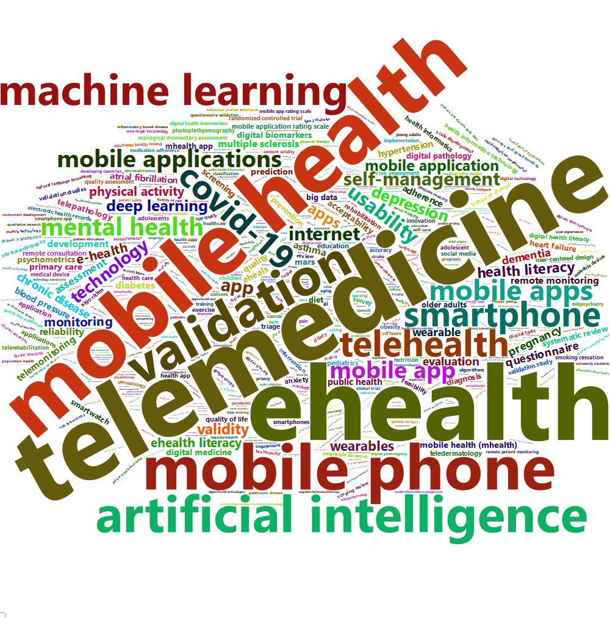

## Wordcloud Mesh Terms

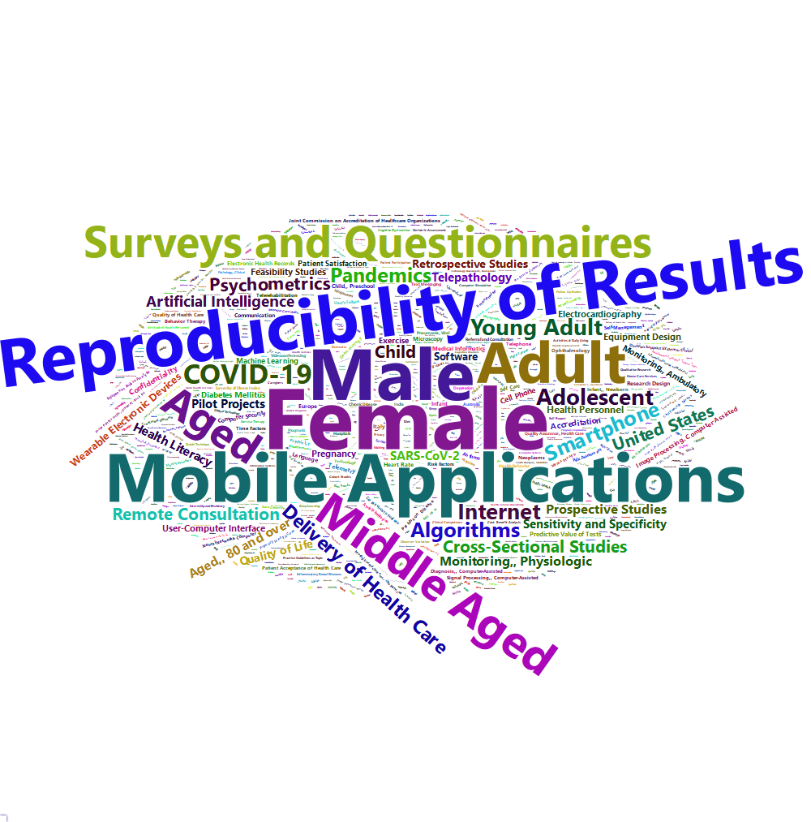

## Descriptive tables

- Global; n=1421

Summary descriptives table

|  | [ALL] | N |
| --- | --- | --- |
|  | N=528 |  |
| Epidemiologic design: |  | 528 |
| Case-control | 2 (0.38%) |  |
| Clinical Trial | 218 (41.3%) |  |
| Cohort | 61 (11.6%) |  |
| Cross-sectional | 193 (36.6%) |  |
| Systematic review | 54 (10.2%) |  |
| Study type: |  | 474 |
| Experimental | 218 (46.0%) |  |
| Observational | 256 (54.0%) |  |

Summary descriptives table

|  | [ALL] |
| --- | --- |
|  | N=1421 |
| Design or dimension term: Yes | 1030 (72.5%) |
| Concordance study: No | 1421 (100%) |
| Predictive study: Yes | 109 (7.67%) |
| Questionare validation: Yes | 41 (2.89%) |

Summary descriptives table

|  | [ALL] |
| --- | --- |
|  | N=1421 |
| Usability - Satisfaction: Yes | 261 (18.4%) |
| Security - Privacy: Yes | 196 (13.8%) |
| Feasibility - Proof of concept: Yes | 150 (10.6%) |
| Functionality: Yes | 99 (6.97%) |
| Effectiveness: Yes | 136 (9.57%) |
| Efficacy: Yes | 82 (5.77%) |
| Efficiency / Cost-utility: Yes | 107 (7.53%) |
| Implementation: Yes | 92 (6.47%) |

Summary descriptives table by groups of `Study type’

|  | Experimental | Observational | p.overall | N |
| --- | --- | --- | --- | --- |
|  | N=218 | N=256 |  |  |
| Usability - Satisfaction: Yes | 51 (23.4%) | 58 (22.7%) | 0.936 | 474 |
| Security - Privacy: Yes | 30 (13.8%) | 32 (12.5%) | 0.788 | 474 |
| Feasibility - Proof of concept: Yes | 47 (21.6%) | 21 (8.20%) | <0.001 | 474 |
| Functionality: Yes | 12 (5.50%) | 8 (3.12%) | 0.291 | 474 |
| Effectiveness: Yes | 42 (19.3%) | 20 (7.81%) | <0.001 | 474 |
| Efficacy: Yes | 25 (11.5%) | 14 (5.47%) | 0.028 | 474 |
| Efficiency / Cost-utility: Yes | 19 (8.72%) | 19 (7.42%) | 0.728 | 474 |
| Implementation: Yes | 14 (6.42%) | 15 (5.86%) | 0.950 | 474 |

## Journal Description by Domain

|  | Overall (N=2061) |
| --- | --- |
| Journal |  |
| HEALTH CARE SCIENCES | 443 (21.5%) |
| Others | 388 (18.8%) |
| MEDICAL INFORMATICS | 383 (18.6%) |
| PUBLIC, ENVIRONMENTAL & OCCUPATIONAL HEALTH | 192 (9.3%) |
| COMPUTER SCIENCE | 75 (3.6%) |
| PSYCHIATRY | 72 (3.5%) |
| ENGINEERING | 71 (3.4%) |
| MEDICINE, GENERAL & INTERNA | 52 (2.5%) |
| CARDIAC & CARDIOVASCULAR SYSTEMS | 46 (2.2%) |
| CLINICAL NEUROLOGY | 42 (2.0%) |
| NURSING | 40 (1.9%) |
| HEALTH POLICY & SERVICES | 36 (1.7%) |
| PATHOLOGY - SCIE | 33 (1.6%) |
| CHEMISTRY | 30 (1.5%) |
| INSTRUMENTS | 30 (1.5%) |
| NEUROSCIENCES | 29 (1.4%) |
| ENVIRONMENTAL SCIENCES | 28 (1.4%) |
| MULTIDISCIPLINARY SCIENCES | 26 (1.3%) |
| PSYCHOLOGY | 23 (1.1%) |
| MEDICINE, RESEARCH & EXPERIMENTAL | 22 (1.1%) |

Others: frequency < 1%

### Figura

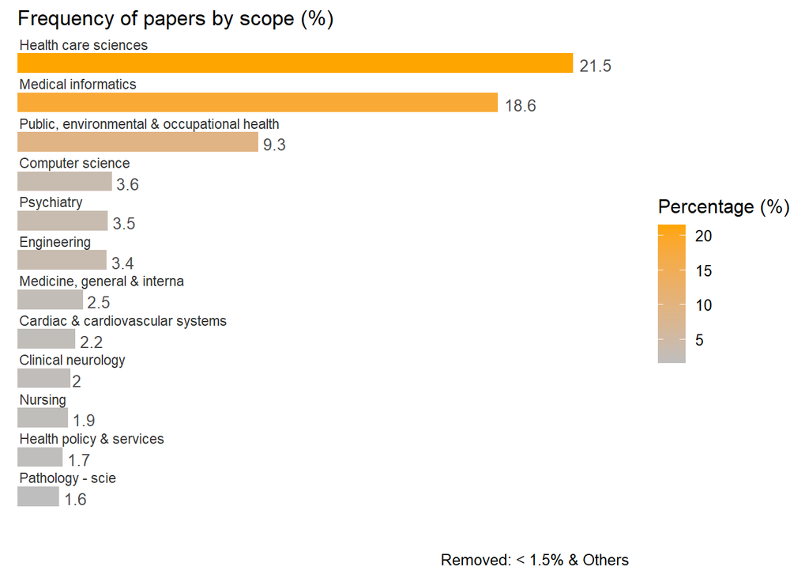

## Evolution of the frequency of published papers

- According to quartile journal
- According to scope of the journal

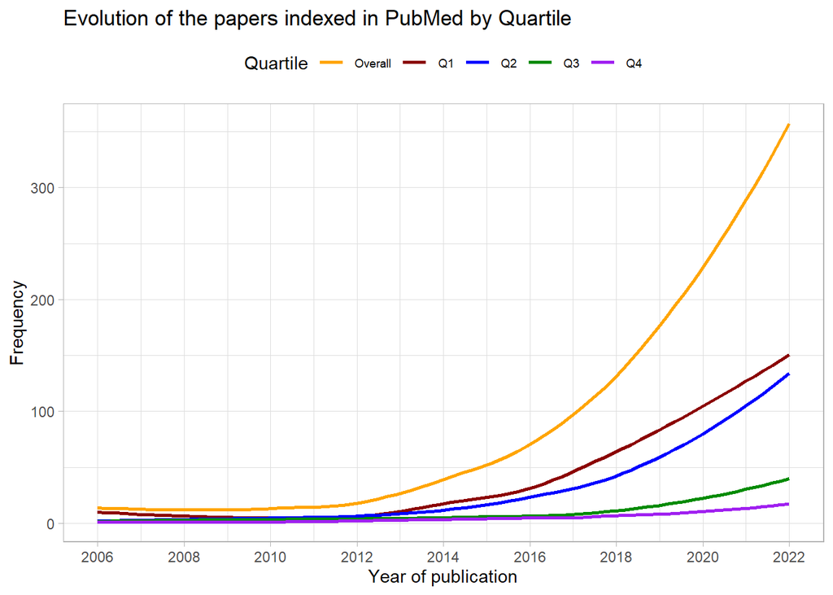

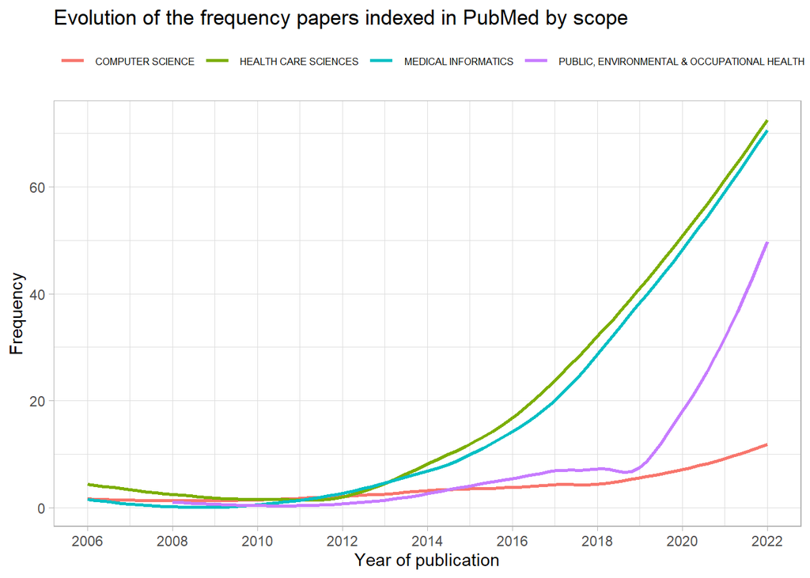

## Frequency papers by country and region

| Author_country | n | % |
| --- | --- | --- |
| UNITED STATES | 273 | 24.20 |
| UNITED KINGDOM | 91 | 8.07 |
| AUSTRALIA | 78 | 6.91 |
| GERMANY | 69 | 6.12 |
| SPAIN | 63 | 5.59 |
| ITALY | 54 | 4.79 |
| CANADA | 52 | 4.61 |
| FRANCE | 35 | 3.10 |
| CHINA | 34 | 3.01 |
| SWITZERLAND | 32 | 2.84 |
| INDIA | 30 | 2.66 |
| THE NETHERLANDS | 30 | 2.66 |
| BRAZIL | 29 | 2.57 |
| NETHERLANDS | 22 | 1.95 |
| REPUBLIC OF KOREA | 19 | 1.68 |
| BELGIUM | 15 | 1.33 |
| MALAYSIA | 15 | 1.33 |
| SWEDEN | 15 | 1.33 |
| JAPAN | 13 | 1.15 |

|  | Overall (N=1421) |
| --- | --- |
| subregion |  |
| Australia and New Zealand | 86 (6.1%) |
| Eastern Asia | 60 (4.2%) |
| Eastern Europe | 14 (1.0%) |
| Latin America and the Caribbean | 47 (3.3%) |
| Northern Africa | 2 (0.1%) |
| Northern America | 325 (22.9%) |
| Northern Europe | 145 (10.2%) |
| South-eastern Asia | 31 (2.2%) |
| Southern Asia | 39 (2.7%) |
| Southern Europe | 139 (9.8%) |
| Sub-Saharan Africa | 24 (1.7%) |
| Western Asia | 32 (2.3%) |
| Western Europe | 184 (12.9%) |
| Missing | 293 (20.6%) |
| region |  |
| Africa | 26 (1.8%) |
| Americas | 372 (26.2%) |
| Asia | 162 (11.4%) |
| Europe | 482 (33.9%) |
| Oceania | 86 (6.1%) |
| Missing | 293 (20.6%) |

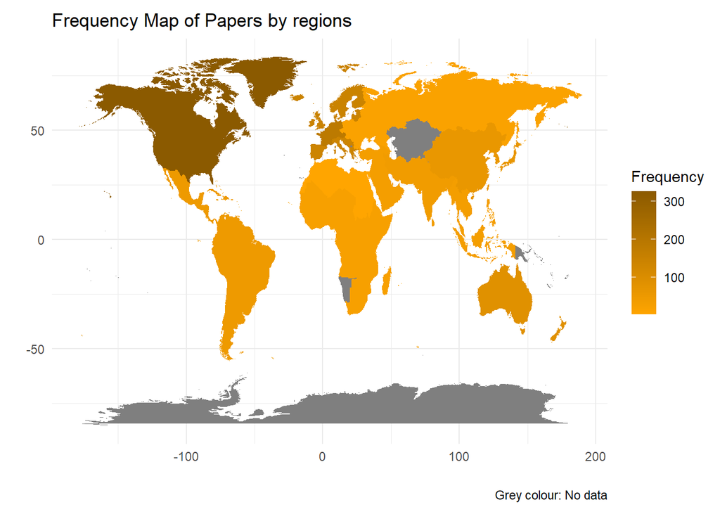

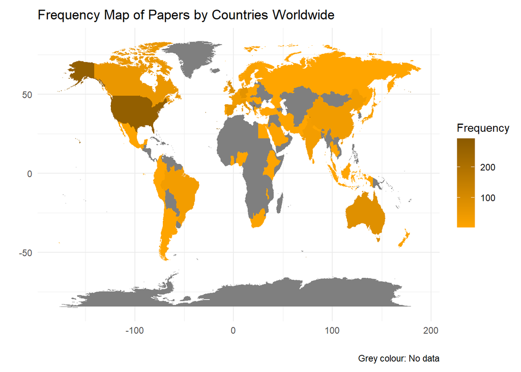

# References

```

A work by Jordi Real

CVCSD

*https://github.com/CVCSD*

Brownrigg, Ray. 2022. *Maps: Draw Geographical Maps*. https://CRAN.R-project.org/package=maps.

Lang, Dawei, and Guan-tin Chien. 2018. *Wordcloud2: Create Word Cloud by Htmlwidget*. https://github.com/lchiffon/wordcloud2.

R Core Team. 2022. *R: A Language and Environment for Statistical Computing*. Vienna, Austria: R Foundation for Statistical Computing. https://www.R-project.org/.

Subirana, Isaac. 2022. *compareGroups: Descriptive Analysis by Groups*. www.comparegroups.eu.

Subirana, Isaac, Héctor Sanz, and Joan Vila. 2014. “Building Bivariate Tables: The compareGroups Package for R.” *Journal of Statistical Software* 57 (12): 1–16. https://www.jstatsoft.org/v57/i12/.

Wickham, Hadley, Winston Chang, Lionel Henry, Thomas Lin Pedersen, Kohske Takahashi, Claus Wilke, Kara Woo, Hiroaki Yutani, Dewey Dunnington, and Teun van den Brand. 2024. *Ggplot2: Create Elegant Data Visualisations Using the Grammar of Graphics*. https://CRAN.R-project.org/package=ggplot2.